# O1M2: TPP hit calling and scoring

# General settings

```r
knitr::opts_chunk$set(
  echo = TRUE,
  warning = FALSE,
  message = FALSE,
  include = TRUE,
  cache = TRUE,
  cache.lazy = FALSE,
  eval = TRUE
  # fig.width = 6*(1+sqrt(5))/2, fig.height = 6 #golden ratio
)

knitr::opts_knit$set(root.dir = "C:/Users/burtsche/Documents/COSMOS-TPP_paper")
```

## Load packages

```r
library(tidyverse)
library("reshape2")
library(OmnipathR)
#library(xlsx)
library(viridis)
library(ggrepel)
options(connectionObserver = NULL)
library(org.Hs.eg.db)
library(visNetwork)
library(knitr)
library(UpSetR)
library(TPP2D)
library(cowplot)
library(ReactomePA)

mutate <- dplyr::mutate
select <- dplyr::select
group_by <- dplyr::group_by
```

## Functions

```r
GSE_RPA <- function(geneList, universe) {
  geneList <- mapIds(org.Hs.eg.db, geneList, "ENTREZID", "SYMBOL")
  universe <- mapIds(org.Hs.eg.db, universe,'ENTREZID','SYMBOL')
  pathway_enrichment <- enrichPathway(
    gene = geneList,
    organism = "human",
    pvalueCutoff = 1,
    pAdjustMethod = "BH",
    qvalueCutoff = 1,
    universe = universe,
    minGSSize = 5,
    maxGSSize = 500,
    readable = TRUE
  )
}
```

```r
values_effect <- c(
  "stabilized" = "darkcyan",
  "destabilized" = "aquamarine3",
  "increased abundance" = "maroon",
  "decreased abundance" = "salmon"
)
```

## Load data

```r
TPP2D_UWB <- read.table("data/2DTPP_UWB_Ola_2021-03-24.txt", row.names = 1, sep = "\t")
phosphoproteomics <- read_tsv("data/LIMMA_results_PhosphoFollowUp_Phospho.txt")


load("data/KSN.RData")
load("data/210802_limma_UWB1.289_initialdataset_correctedphospho.RData")
load("data/220510_viper_footprints.RData")
```

Aggregate and filter TPP UWB data to considered condition and quality criteria.

```r
proteins_merged <- TPP2D_UWB %>%
  filter(condition == "Olaparib 24h") %>%
  # convert temperature to numeric
  mutate(
    qupm = as.numeric(qupm),
    temperature = as.numeric(gsub("C", "", temperature)),
    gene_name = paste(representative, gene_name, sep = ".")
  ) %>%
  # filter proteins which were found with qupm > 1 at least once
  group_by(gene_name) %>%
  filter(any(qupm > 1)) %>%
  ungroup() %>%
  # extract relevant FCs
  dplyr::select(gene_name, matches("rel_fc_protein_.+uM$"), temperature, hit_call) %>%
  melt(id.vars = c("gene_name", "temperature", "hit_call")) %>%
  mutate(concentration = as.numeric(sub("^.*_(.+)uM$", "\\1", variable))) %>%
  # convert FC to log2fc
  mutate(log2_value = log2(value))
```

# TPP hit calling

The permutation takes one night!!! Don’t run this chunk per default (eval=F).

```r
TPPstatistical_input <- list()
for (file in c(
  "TPPraw_uwb_ola24_48.csv", "TPPraw_uwb_ola24_49.csv", "TPPraw_uwb_ola24_50.csv",
  "TPPraw_uwb_ola24_51.csv", "TPPraw_uwb_ola24_52.csv", "TPPraw_uwb_ola24_53.csv"
)) {
  tmp_file <- read_csv(paste0("data/raw/", file))
  tmp_file <- tmp_file %>%
    mutate(
      gene_name = `Gene name`, # paste(`Gene name`, Accession, sep = "."),
      protein_id = Accession
    ) %>% # c("1": as.character(nrow(tmp_file))),
    # protein_id = as.character(protein_id))  %>%
    dplyr::select(protein_id, gene_name, QUPM, matches("sumionarea"), matches("fold change")) %>%
    setNames(c(
      "protein_id", "gene_name", "qupm", "signal_sum_126", "signal_sum_127L", "signal_sum_127H", "signal_sum_128L", "signal_sum_128H",
      "signal_sum_129L", "signal_sum_129H", "signal_sum_130L", "signal_sum_130H", "signal_sum_131L", "rel_fc_126", "rel_fc_127L", "rel_fc_127H",
      "rel_fc_128L", "rel_fc_128H", "rel_fc_129L", "rel_fc_129H", "rel_fc_130L", "rel_fc_130H", "rel_fc_131L"
    )) %>%
    mutate_at(.funs = ~ . / rel_fc_128H, .vars = c("rel_fc_126", "rel_fc_127L", "rel_fc_127H", "rel_fc_128L", "rel_fc_128H"))

  TPPstatistical_input <- append(TPPstatistical_input, list(tmp_file))
}


data("config_tab")
data("raw_dat_list")

names(TPPstatistical_input) <- c("exp1", "exp2", "exp3", "exp4", "exp5", "exp6")

configuration <- config_tab %>%
  mutate(
    Compound = "Olaparib",
    Temperature = c(42.1, 44.1, 46.2, 48.1, 50.4, 51.9, 54, 56.1, 58.2, 60.1, 62.4, 63.9),
    RefCol = c("128H", "131L", "128H", "131L", "128H", "131L", "128H", "131L", "128H", "131L", "128H", "131L"),
    `126` = c("10", "-", "10", "-", "10", "-", "10", "-", "10", "-", "10", "-"),
    `127L` = c("4", "-", "4", "-", "4", "-", "4", "-", "4", "-", "4", "-"),
    `127H` = c("1", "-", "1", "-", "1", "-", "1", "-", "1", "-", "1", "-"),
    `128L` = c("0.4", "-", "0.4", "-", "0.4", "-", "0.4", "-", "0.4", "-", "0.4", "-"),
    `128H` = c("0", "-", "0", "-", "0", "-", "0", "-", "0", "-", "0", "-"),
    `129L` = c("-", "10", "-", "10", "-", "10", "-", "10", "-", "10", "-", "10"),
    `129H` = c("-", "4", "-", "4", "-", "4", "-", "4", "-", "4", "-", "4"),
    `130L` = c("-", "1", "-", "1", "-", "1", "-", "1", "-", "1", "-", "1"),
    `130H` = c("-", "0.4", "-", "0.4", "-", "0.4", "-", "0.4", "-", "0.4", "-", "0.4"),
    `131L` = c("-", "0", "-", "0", "-", "0", "-", "0", "-", "0", "-", "0")
  )

import_df <- import2dDataset(
  configTable = configuration,
  data = TPPstatistical_input,
  idVar = "protein_id",
  intensityStr = "signal_sum_",
  fcStr = "rel_fc_",
  nonZeroCols = "qupm",
  geneNameVar = "gene_name",
  addCol = NULL,
  qualColName = "qupm",
  naStrs = c("NA", "n/d", "NaN"),
  concFactor = 1e6,
  medianNormalizeFC = TRUE,
  filterContaminants = TRUE
)

recomp_sig_df <- recomputeSignalFromRatios(import_df)
preproc_df <- resolveAmbiguousProteinNames(recomp_sig_df)
model_params_df <- getModelParamsDf(
  df = preproc_df
)

fstat_df <- computeFStatFromParams(model_params_df)

set.seed(12, kind = "L'Ecuyer-CMRG")
null_model <- bootstrapNullAlternativeModel(
  df = preproc_df,
  params_df = model_params_df,
  B = 20
)

fdr_tab <- getFDR(
  df_out = fstat_df,
  df_null = null_model
)

hits <- findHits(
  fdr_df = fdr_tab,
  alpha = 0.1
)
TPPFstatistic_hits <- hits %>%
  dplyr::select(clustername, nObs, F_statistic, FDR, slopeH1, detected_effectH1, rssH0, rssH1)

plot2dTppFit(recomp_sig_df, "CHEK2",
  model_type = "H1"
)

save(TPPFstatistic_hits, file = "results/211007_TPPfstathits_UWB24h")
```

Load the results to avoid recalculation

```r
load("data/211007_TPPfstathits_UWB24h.RData")

TPPFstatistic_hits_adap <- TPPFstatistic_hits %>%
  mutate(
    mode = ifelse(detected_effectH1 == "stability" & slopeH1 > 0, "stabilized", NA),
    mode = ifelse(detected_effectH1 == "stability" & slopeH1 < 0, "destabilized", mode),
    mode = ifelse(detected_effectH1 != "stability" & slopeH1 < 0, "decreased abundance", mode),
    mode = ifelse(detected_effectH1 != "stability" & slopeH1 > 0, "increased abundance", mode),
    score = sign(slopeH1) * sqrt(rssH0 - rssH1),
    p_adj = FDR,
    pval = NA,
    hit_call = "TPPFstatistic",
    gene_name = clustername,
    representative = mapIds(org.Hs.eg.db, clustername, "UNIPROT", "SYMBOL")
  ) %>%
  dplyr::select(representative, gene_name, hit_call, mode, score, pval, p_adj)
```

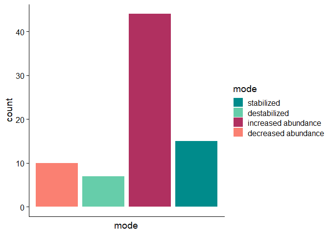

```r
ggplot(TPPFstatistic_hits_adap, aes(x= mode, fill=mode)) +
  geom_bar() +
  scale_fill_manual(values = values_effect) +
  cowplot::theme_cowplot() *
  theme(axis.text.x = element_blank(), axis.ticks.x = element_blank())
```

# TPP hit evaluation Evaluation

## Pathways

Check pathway enrichment for de/stabilized hits

```r
pathway_check_input <- TPPFstatistic_hits_adap %>%
  filter(p_adj < 0.05)


pathways_universe <- proteins_merged %>%
  separate(gene_name, into = c("representative", "gene_name"), sep = "\\.")%>%
  distinct(gene_name)

pathway_enrichment <- pathway_check_input %>%
  mutate(enrichment = list(as.data.frame(GSE_RPA(
    geneList = gene_name,
    universe = pathways_universe$gene_name
  ))))

pathway_enrichment_unnest <- pathway_enrichment %>%
  distinct(gene_name, enrichment) %>%
  distinct(enrichment) %>%
  unnest()

pathway_enrichment_significant <- pathway_enrichment_unnest %>%
  filter(qvalue < 0.05)
```

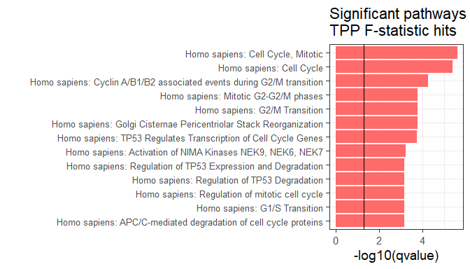

```r
# extract top10 pathways for plot
top_TPP_pathways_TPPFstatistic <- pathway_enrichment_significant %>%
  as.data.frame() %>%
  top_n(10, wt = -log10(qvalue))

p_pathway_UWB1.289_TPPFstatistic <- ggplot(top_TPP_pathways_TPPFstatistic, aes(y = -log10(qvalue), x = reorder(Description, -log10(qvalue)))) +
  geom_bar(stat = "identity", position = position_dodge(), fill = "indianred1") +
  geom_hline(yintercept = -log10(0.05)) +
  coord_flip() +
  theme_bw(base_size = 14) +
  theme(axis.text.y = element_text(size = 10)) +
  labs(x = "", title = "Significant pathways\nTPP F-statistic hits")
p_pathway_UWB1.289_TPPFstatistic
```

## Phosphorylation

Assess changes on phosphoproteomic level and their impact on TPP proteins

```r
psites <- phosphoproteomics %>%
  mutate(
    gene_name = mapIds(org.Hs.eg.db, representative, "SYMBOL", "UNIPROT"),
    condition_long = paste(condition, comparison, sep = "_"),
    UP = representative,
    GeneSymbol = gene_name,
    aa = str_extract(psite, "[[:upper:]]"),
    pos = as.numeric(str_extract(psite, "\\d{1,4}")),
    ID_cosmos = paste(GeneSymbol, "_", aa, pos, sep = ""),
    ID_cosmos = gsub(",.+$", "", ID_cosmos))%>%
  filter(!is.na(logFC) & !is.na(ID_cosmos)&comparison == "Ola") %>%
  dplyr::mutate(
    condition_long = stringr::str_replace(condition_long, "_Ola", "uM"),
    condition_long = stringr::str_replace(condition_long, "BRCA_hom", "UWB1.289_BRCA1"),
    condition_long = stringr::str_replace(condition_long, "BRCA_nul", "UWB1.289"),
    condition_long = stringr::str_replace(condition_long, "04", "0.4")
  ) %>%
  filter(condition_long == "UWB1.289_24h_4uM") %>%
  distinct(ID_cosmos, condition_long, .keep_all = T) %>%
  dplyr::select(ID_cosmos, gene_name, logFC, t, condition_long, adj.P.Val)

TPP_hits_phosphositelevel <- inner_join(TPPFstatistic_hits_adap, psites, by = "gene_name") %>%
  #filter(hit_call != "footprinting") %>%3
  mutate(significance = ifelse(adj.P.Val < 0.05, "significant", "not significant"))
```

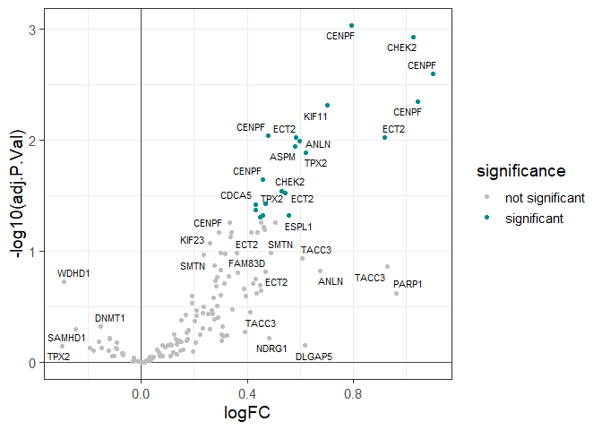

```r
volcano_affected_psites <- ggplot(TPP_hits_phosphositelevel,
                                  aes(x = logFC, y = -log10(adj.P.Val))) +
  geom_hline(yintercept = 0, colour = "gray28")+
  geom_vline(xintercept = 0, colour = "gray28")+
  geom_point(aes(colour = significance))+
  geom_text_repel(label = TPP_hits_phosphositelevel$gene_name, size = 3, colour = "gray2") +
  scale_colour_manual(values = c("grey", "darkcyan")) +
  theme_bw(base_size = 14)
volcano_affected_psites
```

# TPP activities

To estimate the activity of TPP hits we searched for consistent edges between upstream kinases identified by viper and downstream TPP proteins.

```r
# load viper results
viper_phospho_top <- viperRes_phospho_corrected %>%
  group_by(condition_long) %>%
  top_n(30, wt = absNES)

viper_trans_top <- viperRes_trans %>%
  group_by(condition_long) %>%
  top_n(30, wt = absNES)
```

```r
# filter prior knowledge links
annoated_ptms_measured <- KSN %>%
  separate(substrate_genesymbol, into = c("substrate_genesymbol", "site"), sep = "_") %>%
  # subset prior knowledge to subset with measured kinase and target
  filter(enzyme_genesymbol %in% viper_phospho_top$regulator &
    substrate_genesymbol %in% TPPFstatistic_hits_adap$gene_name) %>%
  left_join(viper_phospho_top, by = c("enzyme_genesymbol" = "regulator")) %>%
  # predict for each psite an activation state based on the upstream kinase activity
  mutate(Kinase_activity = sign(NES)) %>%
  dplyr::select(enzyme_genesymbol, sign, substrate_genesymbol, site, Kinase_activity) %>%
  mutate(substrate_activity_predicted =sign*Kinase_activity)
```

## Combine TPP activity information for COSMOS

```r
TPP_cosmos_input <- annoated_ptms_measured %>%
  # only keep TPP proteins for which there is consistent activation or inactivation information
  # necessary because we do not no which upstream kinase is potentially regulating the TPP protein
  # the others can be modelled active or inactive supported by (de)stabilization information
  distinct(TPP_protein = substrate_genesymbol, substrate_activity_predicted) %>%
  group_by(TPP_protein) %>%
  summarise(substrate_activity_predicted_summ = sign(mean(substrate_activity_predicted)))

# aggregate final COSMOS input df
TPP_cosmos_input_final <- TPP_cosmos_input %>%
  mutate(substrate_activity_predicted_summ = ifelse(substrate_activity_predicted_summ == 0, NaN, substrate_activity_predicted_summ)) %>%
  bind_rows(data.frame(TPP_protein = TPPFstatistic_hits_adap$gene_name, substrate_activity_predicted_summ = NaN)) %>%
  distinct(TPP_protein, .keep_all = T)
```

# Remove inconsistent edges

To support the optimization to model consistent links between kinases and TPP proteins as assumed for the activity estimation, we removed incosistent prior knowledge edges.

For example: Kinase (active) –activates_via_S10–> TPP protein (S10 dephosphorylated) would be removed, because the dephosphorylation of this psite can not be explained using this link (but this information is not always reflected in TPP activity).

```r
# Format phosphoproteomics data after intensity correction
psites_corrected <- limma_UWB1.289_initialdataset_correctedphospho %>%
  filter(condition == "BRCA_nul_24h_4" & comparison == "Ola") %>%
  mutate(
    gene_name = mapIds(org.Hs.eg.db, representative, "SYMBOL", "UNIPROT"),
    condition_long = paste(condition, comparison, sep = "_"),
    UP = representative,
    GeneSymbol = gene_name,
    aa = str_extract(psite, "[[:upper:]]"),
    pos = as.numeric(str_extract(psite, "\\d{1,4}"))
  ) %>%
  mutate(ID_cosmos = paste(GeneSymbol, "_", aa, pos, sep = "")) %>%
  dplyr::select(ID_cosmos, logFC, t, condition_long) %>%
  filter(!is.na(logFC) & !is.na(ID_cosmos)) %>%
  mutate(ID_cosmos = gsub(",.+$", "", ID_cosmos))


# format KSN

KSN <- KSN %>%
  separate(col = substrate_genesymbol, c("substrate_protein", "psite"), remove = FALSE)
```

Format footprinting and TPP results and prepare for end object which is exported for COSMOS.

```r
Kinases_input_COSMOS <- sign(viper_phospho_top$NES)
names(Kinases_input_COSMOS) <- paste0(
  "X",
  mapIds(org.Hs.eg.db, viper_phospho_top$regulator, "ENTREZID", "SYMBOL")
)
Kinases_input_COSMOS <- Kinases_input_COSMOS[names(Kinases_input_COSMOS) != "XNA"]

TPPFstatistic_hits_adap <- TPPFstatistic_hits_adap %>%
  mutate(signed_score = ifelse(mode == "destabilized" | mode == "decreased abundance", -1, 1))
```

## Combine prior knowledge, phosphorylation and TPP

Perform the kinase sign filtering to remove links btw kianses and TPP proteins

```r
# extract kinase targets from TPP proteins
kinase_targets <- TPPFstatistic_hits_adap %>%
  filter(gene_name %in% KSN$substrate_protein) %>%
  mutate(cosmosID = paste0("X", mapIds(org.Hs.eg.db,gene_name, "ENTREZID", "SYMBOL")))

# merge with limma results
KSN_withFCs <- KSN %>%
  left_join(psites, by = c("substrate_genesymbol" = "ID_cosmos")) %>%
  dplyr::select(-condition_long)
KSN_TPPtargets <- KSN_withFCs %>%
  filter(substrate_protein %in% kinase_targets$gene_name) %>%
  mutate(source_cosmos =  paste0("X", mapIds(org.Hs.eg.db, enzyme_genesymbol, "ENTREZID", "SYMBOL")))

# use edges with viper kinase
inputs <- Kinases_input_COSMOS[names(Kinases_input_COSMOS) %in% KSN_TPPtargets$source_cosmos]

# merge
KSN_TPPtargets$kinase_sign <- sapply(KSN_TPPtargets$source_cosmos, function(x, inputs) {
  if (x %in% names(inputs)) {
    return(as.numeric(inputs[x]))
  } else {
    return(NA)
  }
}, inputs = inputs)

# remove edges without kinase measurement
KSN_TPPtargets_filt <- filter(KSN_TPPtargets, !is.na(logFC) & !is.na(kinase_sign))
# get inconsistent edges
KSN_TPPtargets_filt <- KSN_TPPtargets_filt %>%
  filter(sign(logFC * sign) != sign(kinase_sign)) %>%
  select(substrate_genesymbol, enzyme_genesymbol, sign, logFC, kinase_sign)

KSN_TPPtargets_filt
```

```
##   substrate_genesymbol enzyme_genesymbol sign       logFC kinase_sign
## 1           CDCA5_T159              CDK1    1 -0.06879140           1
## 2            CDCA5_S75              CDK1    1 -0.11694422           1
## 3             RRN3_S44              CDK2    1 -0.02706761           1
```

# Save

```r
save(TPP_cosmos_input_final, viper_trans_top, viper_phospho_top, KSN_TPPtargets_filt,
    file = "220512_cosmosinput_merged.RData")
```